# Winning Jeopardy

Sofiane Ikkour

#### **Context and goal:**

Jeopardy is a popular TV show in the US where participants answer trivia to win money. Participants are given a set of categories to choose from and a set of questions that increase in difficulty. As the questions get more difficult, the participant can earn more money for answering correctly.

In June 2019, contestant James Holzhauer ended a 32-game winning streak, just barely missing the record for highest winnings. James Holzhauer dedicated hours of effort to optimizing what he did during a game to maximize how much money he earned. To achieve what he did, James had to learn and master the vast amount of trivia that Jeopardy can throw at the contestants.

Let’s say we want to compete on Jeopardy like James. As he did, we’ll have to familiarize ourselves with an enormous amount of trivia to be competitive. Given the vastness of the task, is there a way that we can somehow simplify our studies and prioritize topics that appear more often in Jeopardy?

#### **Dataset:**

In this use case, we’ll work with a dataset of Jeopardy questions to figure out some patterns in the questions that could help us win.  
the dataset is named jeopardy.csv and contain a subset of 20000 rows from much larger dataset of Jeopardy questions. Here’s the beginning of the file:

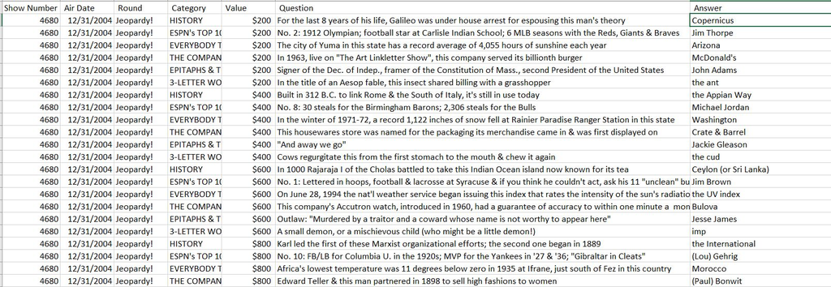

.

Each row represents a single question from a single episode of Jeopardy. Crucially, we can see the different question categories that appeared on a particular episode, the questions and answers themselves, and the value associated with the question.

**Note:** This code was written on RStudio.  
**Language:** R.  
**Packages:** readr, dplyr, stringr, tidyr, tibble.

**Load and read the dataset**

```r
# load the relevant libraries
library(readr)
library(dplyr)
library(stringr)
library(tidyr)
library(tibble)

# set the working directory
setwd("C:/Users/Aylan/Documents/IT/DataQuest/R/Winning Jeopardy")

# read the dataset
jeopardy <- read_csv("jeopardy.csv")
# print the first five rows of the dataset
head(jeopardy, 5)
```

```
## # A tibble: 5 x 7
##   `Show Number` `Air Date` Round     Category     Value Question          Answer
##           <dbl> <date>     <chr>     <chr>        <chr> <chr>             <chr>
## 1          4680 2004-12-31 Jeopardy! HISTORY      $200  "For the last 8 ~ Coper~
## 2          4680 2004-12-31 Jeopardy! ESPN's TOP ~ $200  "No. 2: 1912 Oly~ Jim T~
## 3          4680 2004-12-31 Jeopardy! EVERYBODY T~ $200  "The city of Yum~ Arizo~
## 4          4680 2004-12-31 Jeopardy! THE COMPANY~ $200  "In 1963, live o~ McDon~
## 5          4680 2004-12-31 Jeopardy! EPITAPHS & ~ $200  "Signer of the D~ John ~
```

**Data cleaning:**

```r
# print the column names
colnames(jeopardy)
```

```
## [1] "Show Number" "Air Date"    "Round"       "Category"    "Value"
## [6] "Question"    "Answer"
```

The column names need some formatting.

```r
# replace white spaces by underscores for each column name
# and lower all the column names
colnames(jeopardy) <- colnames(jeopardy) %>%
  str_replace_all(" ", "_") %>%
  str_to_lower()

# print the column names to see the results
colnames(jeopardy)
```

```
## [1] "show_number" "air_date"    "round"       "category"    "value"
## [6] "question"    "answer"
```

The column value is of type character. we would ewpect this column to be numeric.  
Let’s display the unique values of this column.

```r
# print the unique values of the column value
unique(jeopardy$value)
```

```
##  [1] "$200"    "$400"    "$600"    "$800"    "$2,000"  "$1000"   "$1200"
##  [8] "$1600"   "$2000"   "$3,200"  "None"    "$5,000"  "$100"    "$300"
## [15] "$500"    "$1,000"  "$1,500"  "$1,200"  "$4,800"  "$1,800"  "$1,100"
## [22] "$2,200"  "$3,400"  "$3,000"  "$4,000"  "$1,600"  "$6,800"  "$1,900"
## [29] "$3,100"  "$700"    "$1,400"  "$2,800"  "$8,000"  "$6,000"  "$2,400"
## [36] "$12,000" "$3,800"  "$2,500"  "$6,200"  "$10,000" "$7,000"  "$1,492"
## [43] "$7,400"  "$1,300"  "$7,200"  "$2,600"  "$3,300"  "$5,400"  "$4,500"
## [50] "$2,100"  "$900"    "$3,600"  "$2,127"  "$367"    "$4,400"  "$3,500"
## [57] "$2,900"  "$3,900"  "$4,100"  "$4,600"  "$10,800" "$2,300"  "$5,600"
## [64] "$1,111"  "$8,200"  "$5,800"  "$750"    "$7,500"  "$1,700"  "$9,000"
## [71] "$6,100"  "$1,020"  "$4,700"  "$2,021"  "$5,200"  "$3,389"
```

It turns out that each numeric value is associated with a dollar sign. Another value is “None”.  
In the next step, we will remove all the rows containing the value “None” in the value column and replace the dollar sign with empty space to remove it. Finally, we’ll convert the entire column into a numeric column.

```r
# remove the rows with the value "None" in the value column
jeopardy_clean <- jeopardy %>%
  filter(value != "None") %>%
  mutate(
    value = str_replace_all(value, "[$,]", ""),
    value = as.numeric(value)
  )

# print again the unique values of the column value
print(unique(jeopardy_clean$value))
```

```
##  [1]   200   400   600   800  2000  1000  1200  1600  3200  5000   100   300
## [13]   500  1500  4800  1800  1100  2200  3400  3000  4000  6800  1900  3100
## [25]   700  1400  2800  8000  6000  2400 12000  3800  2500  6200 10000  7000
## [37]  1492  7400  1300  7200  2600  3300  5400  4500  2100   900  3600  2127
## [49]   367  4400  3500  2900  3900  4100  4600 10800  2300  5600  1111  8200
## [61]  5800   750  7500  1700  9000  6100  1020  4700  2021  5200  3389
```

```r
# print the column types
print(typeof(jeopardy_clean$value))
```

```
## [1] "double"
```

The data contains text which contains punctuation and different capitalization. The text needs to be processed or normalized. More specifically, we need to lowercase all letters and remove any punctuation. For this step, we’ll normalize the question, answer and category columns.

```r
jeopardy_clean <-  jeopardy_clean %>%
  mutate(
    question = tolower(question),
    question = str_replace_all(question, "[^A-Za-z0-9 ]", ""),
    answer = tolower(answer),
    answer = str_replace_all(answer, "[^A-Za-z0-9 ]", ""),
    category = tolower(category),
    category = str_replace_all(category, "[^A-Za-z0-9 ]", "")
  )

# check the result
head(jeopardy_clean,10)
```

```
## # A tibble: 10 x 7
##    show_number air_date   round     category    value question           answer
##          <dbl> <date>     <chr>     <chr>       <dbl> <chr>              <chr>
##  1        4680 2004-12-31 Jeopardy! history       200 for the last 8 ye~ copern~
##  2        4680 2004-12-31 Jeopardy! espns top ~   200 no 2 1912 olympia~ jim th~
##  3        4680 2004-12-31 Jeopardy! everybody ~   200 the city of yuma ~ arizona
##  4        4680 2004-12-31 Jeopardy! the compan~   200 in 1963 live on t~ mcdona~
##  5        4680 2004-12-31 Jeopardy! epitaphs  ~   200 signer of the dec~ john a~
##  6        4680 2004-12-31 Jeopardy! 3letter wo~   200 in the title of a~ the ant
##  7        4680 2004-12-31 Jeopardy! history       400 built in 312 bc t~ the ap~
##  8        4680 2004-12-31 Jeopardy! espns top ~   400 no 8 30 steals fo~ michae~
##  9        4680 2004-12-31 Jeopardy! everybody ~   400 in the winter of ~ washin~
## 10        4680 2004-12-31 Jeopardy! the compan~   400 this housewares s~ crate ~
```

We can verify that the category, question and answer columns are lower-cased and all special characters and punctuation are removed.

In this last data cleaning step, we need to address the air_date column which is of date type. We’ll separate this column into a year, month and day column and each of these new date columns will be converted into numeric.

```r
# split the air_date column into 3 separate new columns year, month and day
# convert each of the new columns into numeric
jeopardy_clean <- jeopardy_clean %>%
  separate(., air_date, sep = "-", into = (c("year", "month", "day"))) %>%
  mutate(year = as.numeric(year),
            month = as.numeric(month),
            day = as.numeric(day))

# display the first few rows of the dataset
head(jeopardy_clean, 10)
```

```
## # A tibble: 10 x 9
##    show_number  year month   day round     category   value question      answer
##          <dbl> <dbl> <dbl> <dbl> <chr>     <chr>      <dbl> <chr>         <chr>
##  1        4680  2004    12    31 Jeopardy! history      200 for the last~ coper~
##  2        4680  2004    12    31 Jeopardy! espns top~   200 no 2 1912 ol~ jim t~
##  3        4680  2004    12    31 Jeopardy! everybody~   200 the city of ~ arizo~
##  4        4680  2004    12    31 Jeopardy! the compa~   200 in 1963 live~ mcdon~
##  5        4680  2004    12    31 Jeopardy! epitaphs ~   200 signer of th~ john ~
##  6        4680  2004    12    31 Jeopardy! 3letter w~   200 in the title~ the a~
##  7        4680  2004    12    31 Jeopardy! history      400 built in 312~ the a~
##  8        4680  2004    12    31 Jeopardy! espns top~   400 no 8 30 stea~ micha~
##  9        4680  2004    12    31 Jeopardy! everybody~   400 in the winte~ washi~
## 10        4680  2004    12    31 Jeopardy! the compa~   400 this housewa~ crate~
```

**Hypothesis testing:**

We are now in a place where we can properly ask questions from the data and perform meaningful hypothesis tests on it. Given the near infinite amount of questions that can be asked in Jeopardy, we can wonder if any particular subject area has increased relevance in the dataset. We may think that science and history facts are the most common categories to appear in Jeopardy episodes. Others feel that Shakespeare questions gets a lot of attention from Jeopardy.

*H0: Science, History and Shakespeare don’t have higher prevalence in the Jeopardy data.*  
*HA: Science, History and Shakespeare have higher prevalence in the Jeopardy data.*

With the chi-squared test, we can actually test these hypotheses. For this exercise, let’s assess if science, history and Shakespeare have a higher prevalence in the data set. First, we need to develop our null hypotheses. There are around 3369 unique categories in the Jeopardy data set after doing all of our cleaning. We would expect that the probability of picking a random category would be the same no matter what category you picked. This comes out to be 1/3369. This would also mean that the probability of not picking a particular category would be 3368/3369.

Here chi-squared test automatically assumes that the proportions of the categories would be equal, but we can also specify what these proportions should be:

```r
n_questions <- nrow(jeopardy_clean)
p_category_expected <-1/3369
p_not_category_expected <- 3368/3369
p_expected <- c(p_category_expected, p_not_category_expected)
```

Now, we will conduct a hypothesis test for each of the three categories (Science, History and Shakespeare) to see if they are more likely to appear than other categories.

```r
# count how many times the word "science" appears in the category column
count_science_category <- 0
cat <- pull(jeopardy_clean, category)
for (c in cat) {
  if ("science" %in% c) {
    count_science_category <- count_science_category + 1
  }
}

# count how many times the word "science" doesn't appear in the category column
count_not_science_category <- n_questions - count_science_category

# store the two variables in a vector
v_science <- c(count_science_category, count_not_science_category)

# conduct the hypothesis test
chisq.test(v_science, p = p_expected)
```

```
##
##  Chi-squared test for given probabilities
##
## data:  v_science
## X-squared = 145.77, df = 1, p-value < 2.2e-16
```

```r
# count how many times the word "history" appears in the category column
count_history_category <- 0
for (c in cat) {
  if ("history" %in% c) {
    count_history_category <- count_history_category + 1
  }
}

# count how many times the word "history" doesn't appear in the category column
count_not_history_category <- n_questions - count_history_category

# store the two variables in a vector
v_history <- c(count_history_category, count_not_history_category)

# conduct the hypothesis test
chisq.test(v_history, p = p_expected)
```

```
##
##  Chi-squared test for given probabilities
##
## data:  v_history
## X-squared = 200.04, df = 1, p-value < 2.2e-16
```

```r
# count how many times the word "shakespeare" appears in the category column
count_shakespeare_category <- 0
for (c in cat) {
  if ("shakespeare" %in% c) {
    count_shakespeare_category <- count_shakespeare_category + 1
  }
}

# count how many times the word "shakespeare" doesn't appear in the category column
count_not_shakespeare_category <- n_questions - count_shakespeare_category

# store the two variables in a vector
v_shakespeare <- c(count_shakespeare_category, count_not_shakespeare_category)

# conduct the hypothesis test
chisq.test(v_shakespeare, p = p_expected)
```

```
##
##  Chi-squared test for given probabilities
##
## data:  v_shakespeare
## X-squared = 34.381, df = 1, p-value = 4.53e-09
```

We can notice from the three hypotheses that the p-value is less than 0.05.  
Therefore, we can conclude that we can reject the null hypothesis that Science, History and Shakespeare don’t have higher prevalence in the Jeopardy data.

**Another hypothesis test**

Let’s say we want to investigate how often new questions have been used previously or not in future questions. First, we will create a vector that will help us set up for another hypothesis test.

```r
# create an empty vector called terms_used
terms_used <- c()

# sort jeopardy by ascending air_date
jeopardy_clean <- jeopardy_clean %>%
  arrange(year)

# display the first few rows of jeopardy_clean
head(jeopardy_clean)
```

```
## # A tibble: 6 x 9
##   show_number  year month   day round     category      value question    answer
##         <dbl> <dbl> <dbl> <dbl> <chr>     <chr>         <dbl> <chr>       <chr>
## 1          62  1984    12     4 Jeopardy! washington dc   100 what the d~ the d~
## 2          62  1984    12     4 Jeopardy! colors          100 color of a~ red
## 3          62  1984    12     4 Jeopardy! a la cart       100 while 2 of~ a sho~
## 4          62  1984    12     4 Jeopardy! food            100 varieties ~ musta~
## 5          62  1984    12     4 Jeopardy! movie trivia    100 turned dow~ shirl~
## 6          62  1984    12     4 Jeopardy! washington dc   200 the distri~ georg~
```

```r
# split each question into separate words
questions <- pull(jeopardy_clean, question)
for (q in questions) {
  split_questions <- str_split(q, " ")[[1]]
  # check if the words are in terms_used are are greater than 6 letters
  # if yes, add them to terms_used
  for (term in split_questions) {
    if (!term %in% terms_used & nchar(term) >= 6) {
      terms_used <- c(terms_used, term)
  }
 }
}
```

Let’s say we want to study high values associated with it rather than low values. We need to how many high value and low value questions associated with each term. High and low values are defined as follows:

- Low value: Any row where value is less than 800.
- High value: Any row where value is greater or equal than 800.

Below is an image of what the question board looks like at the start of every round:

[figure not shown]

Question board

For each category, we can see that under this definition that for every 2 high value questions, there are 3 low value questions, if the number of low and high value questions is different from the 2:3 ratio, we would have reason to believe that a term would be more prevalent in either the low or high value questions.

Our null and alternative hypotheses are defined as follows:

*H0: Each term is not distributed more to either high or low value questions*  
*Ha: Each term is distributed more to either high or low value questions*

```r
# create an empty dataset that we can add more rows to
count_data <- NULL

# extract the value colum and assign it to a variable named values
values <- pull(jeopardy_clean, value)

# iterate through each term in terms_used
for (term in terms_used[1:20]) {
  n_high_value <- 0
  n_low_value <- 0
  # check if the term is present in the question
  # then check if the question is high or low value
  for (i in 1:length(questions)) {
    split_questions <- str_split(questions[i], " ")[[1]]
    if (term %in% split_questions & values[i] >= 800) {
      n_high_value <- n_high_value + 1
    } else if (term %in% split_questions & values[i] < 800) {
      n_low_value <- n_low_value + 1
 }
  }

  # test the null hypothesis for each term
  test <- chisq.test(c(n_high_value, n_low_value), p = c(2/5, 3/5))
  # each term is associated with a high value question count, a low value question count, and a p-value
  # turn these values into a vector and append it to "count_data"
  new_row <- c(term, n_high_value, n_low_value, test$p.value)
  count_data <- rbind(count_data, new_row)
}
# transform the dataset into a tibble
count_data <- as_tibble(count_data)
colnames(count_data) <- c("term", "nhigh", "nlow", "p_value")

# display the first 20 rows of the dataset
head(count_data, 20)
```

```
## # A tibble: 20 x 4
##    term         nhigh nlow  p_value
##    <chr>        <chr> <chr> <chr>
##  1 stands       48    31    0.000165628493835125
##  2 letter       35    35    0.0876687951299294
##  3 wheels       5     6     0.71192315069219
##  4 toward       2     2     0.683091398309609
##  5 produce      2     6     0.386476230771233
##  6 checkout     0     1     0.414216178242525
##  7 varieties    4     15    0.0918238350532231
##  8 include      67    71    0.0403262187600015
##  9 chinese      9     20    0.324365051547162
## 10 turned       28    29    0.159748183670977
## 11 member       22    23    0.22354287457132
## 12 became       122   148   0.0820059228666711
## 13 office       19    30    0.86110827222743
## 14 districts    0     1     0.414216178242525
## 15 oldest       11    28    0.13269546067395
## 16 neighborhood 1     3     0.54029137460742
## 17 johnny       4     12    0.220671361919847
## 18 wearing      7     17    0.278660494899244
## 19 tennis       9     19    0.396065820708938
## 20 touches      1     1     0.772829992684448
```

We can notice from the table that some of the values are less than 5.  
The chi-squared test is prone to errors when the count of each of the cells is less than 5.  
We may discard these terms and look at only the term with the values greater than 5.  
It seems that the term “stands” has the lowest p_value.